# Chapter 2

## Exercises

### Exercise 1

**textbook:** In this situation copy-on-modify prevents the creation of a circular list:

```r
# creates initial object
x <- list()
# Object address
cat(obj_addr(x))
0x7f958f9b9580
# Trace
tracemem(x)
[1] "<0x7f958f9b9580>"
# Copy-on-modify triggers new copy
x[[1]] <- x
tracemem[0x7f958f9b9580 -> 0x7f958fc3edd8]: eval eval withVisible withCallingHandlers handle timing_fn evaluate_call <Anonymous> evaluate in_dir eng_r block_exec call_block process_group.block process_group withCallingHandlers process_file <Anonymous> <Anonymous>
# Copied object has new memory address
cat(obj_addr(x))
0x7f958c2b5ea8
# list element contains old memory address
cat(obj_addr(x[[1]]))
0x7f958f9b9580
```

### Exercise 2

First, we define a function to create some random data.

```r
# Function
create_random_df <- function(nrow, ncol) {
  random_matrix <- matrix(runif(nrow * ncol), nrow = nrow)
  as.data.frame(random_matrix)
}
# Create Data frame
create_random_df(2, 2)
         V1         V2
1 0.3797897 0.43221928
2 0.5858744 0.08298176
```

Next, we wrap the two approaches to subtract numerical values (in our case medians) from each column of a data frame in their own function. We name these functions depending on whether the approach operates on a data frame or a list. For a fairer comparison, the second function also contains the overhead code to convert between data frame and list objects.

```r
# Function for data frame
subtract_df <- function(x, medians) {
  for (i in seq_along(medians)) {
    x[[i]] <- x[[i]] - medians[[i]]
  }
  x
}
# Function for list
subtract_list <- function(x, medians) {
  x <- as.list(x)
  x <- subtract_df(x, medians)
  as.data.frame.list(x)
}
```

This lets us profile the performance, via benchmarks on data frames with differing numbers of columns. Therefore, we create a small helper that creates our random data frame and its medians before it benchmarks the two approaches.

```r
# Function for finding the vector of medians
# given a randomly generated data frame
# then testing performance
benchmark_medians <- function(ncol) {
  df <- create_random_df(nrow = 1e4, ncol = ncol)
  medians <- vapply(df, median, numeric(1), USE.NAMES = FALSE)

  bench::mark(
    "data frame" = subtract_df(df, medians),
    "list" = subtract_list(df, medians)
  )
}
# Test
benchmark_medians(1)
# A tibble: 2 × 6
  expression      min   median `itr/sec` mem_alloc `gc/sec`
  <bch:expr> <bch:tm> <bch:tm>     <dbl> <bch:byt>    <dbl>
1 data frame   17.9µs   46.2µs    20964.    99.1KB     62.9
2 list        106.9µs  141.2µs     6481.    78.2KB     17.4
```

The bench::press() function allows us to run our helper across a grid of parameters. We will use it to slowly increase the number of data frame columns in our benchmark.

```r
results <- bench::press(
  ncol = c(1000, 1500, 2000, 2500, 3000, 3500, 4000),
  benchmark_medians(ncol)
)
Running with:
   ncol
1  1000
2  1500
3  2000
4  2500
5  3000
6  3500
7  4000
```

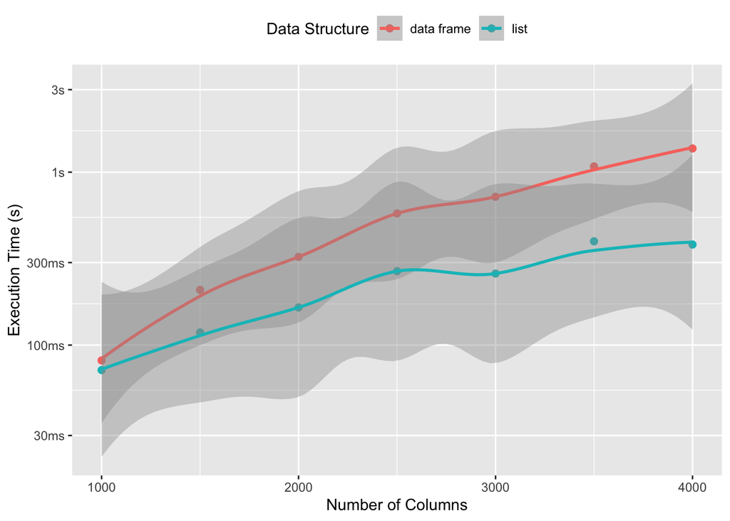

```r
ggplot(results, aes(ncol, median,
  col = attr(expression, "description")
)) +
  geom_point(size = 2) +
  geom_smooth() +
  labs(
    x = "Number of Columns",
    y = "Execution Time (s)",
    color = "Data Structure"
  ) +
  theme(legend.position = "top")
`geom_smooth()` using method = 'loess' and formula 'y ~ x'
```

When working directly with the data frame, the execution time grows quadratically with the number of columns in the input data. This is because (e.g.) the first column must be copied n times, the second column n-1 times, and so on. When working with a list, the execution time increases only linearly.

### Exercise 3

```r
# Create a new environment and bind it to e1
e1 <- rlang::env(a = 1, b = 2, c = 3)
# Trace
tracemem(e1)
# Error in tracemem(e1) :
# 'tracemem' is not useful for promise and environment objects
```

The error occurs because “it is not useful to trace NULL, environments, promises, weak references, or external pointer objects, as these are not duplicated” (see ?tracemem). Environments are always modified in place.

## Unbinding and the garbage collector

```r
# Print a message to the console everytime gc is run
# gcinfo(True)
# Print total number of bytes used
mem_used()
2,998,724,520 B
```